# Отчет по России с использование тестового множества и стандартной формулы для доходности (данные с нулями)

> Период отслеживания менялся от **1** месяца до **12**

> Период ожидания менялся от **0** до **8** недель

> Период инвестирования менялся от **1** месяца до **12**

> Рассматривалась 1 процентиль **0.3**

## ________________________________Россия____________________________

> Количество исследумых компаний – **49**

> Количество портфелей, использованных для подсчета средней доходности – **381**

> Всего было рассмотрено **1296** стратегий

#### **Таблица 1. Все стратегии**

|  | mean | t | p-value | hist_per | moment_per | invest_per | percent | Amount_of_negative |
| --- | --- | --- | --- | --- | --- | --- | --- | --- |
| 1 | 0.024906 | 4.19912 | 3.3e-05 | 4 | 0 | 4 | 0.3 | 138 |
| 2 | 0.025206 | 4.273802 | 2.4e-05 | 4 | 1 | 4 | 0.3 | 145 |
| 3 | 0.026197 | 4.456376 | 1.1e-05 | 4 | 2 | 4 | 0.3 | 146 |
| 4 | 0.026319 | 4.538113 | 8e-06 | 4 | 3 | 4 | 0.3 | 143 |
| 5 | 0.025953 | 4.578063 | 6e-06 | 4 | 4 | 4 | 0.3 | 139 |
| 6 | 0.024759 | 4.214333 | 3.1e-05 | 4 | 5 | 4 | 0.3 | 143 |
| 7 | 0.022907 | 3.964721 | 8.8e-05 | 4 | 6 | 4 | 0.3 | 142 |
| 8 | 0.022245 | 3.808712 | 0.000163 | 4 | 7 | 4 | 0.3 | 141 |
| 9 | 0.022646 | 3.790075 | 0.000175 | 4 | 8 | 4 | 0.3 | 140 |
| 10 | 0.027386 | 4.606955 | 6e-06 | 8 | 0 | 4 | 0.3 | 136 |

[output cut: 1286 more lines]

#### **Таблица 2. Данные, отложенные для теста (не использовались для оценки параметров)**

|  | POLY | YNDX | ALRS | AKRN | AFLT | BSPB | BANE | BANEP | VTBR | VSMO | GAZP | GMKN | DIXY | IRAO | KMAZ | LSRG | LKOH | MVID | MAGN | MTSS | MGNT | MFON | MOEX | MSTT | NLMK | NMTP | NVTK | PIKK | ROSN | … |
| --- | --- | --- | --- | --- | --- | --- | --- | --- | --- | --- | --- | --- | --- | --- | --- | --- | --- | --- | --- | --- | --- | --- | --- | --- | --- | --- | --- | --- | --- | --- |
| 11.07.11 | 0 | 0 | 0 | 1495.9 | 69.49 | 140.94 | 0 | 0 | 0.08457 | 5055 | 201.6 | 7550 | 388 | 0.0385 | 62.43 | 1017.1 | 1838.1 | 279 | 24.884 | 238.85 | 3949.6 | 0 | 0 | 225 | 109.55 | 3.235 | 371.75 | 106.58 | 234 | … |
| 18.07.11 | 0 | 0 | 0 | 1480 | 70.02 | 141.7 | 0 | 0 | 0.08624 | 4811.8 | 202.7 | 7530 | 385 | 0.03835 | 61.35 | 1013.4 | 1875 | 275.54 | 24.941 | 241.01 | 3951 | 0 | 0 | 225.1 | 108.51 | 3.1512 | 412.7 | 107.12 | 241.69 | … |
| 25.07.11 | 0 | 0 | 0 | 1529 | 70.08 | 137.93 | 0 | 0 | 0.08323 | 4825 | 199.44 | 7401 | 377.59 | 0.03987 | 59.7 | 987.9 | 1848 | 267.98 | 23.99 | 240.5 | 3955 | 0 | 0 | 220.38 | 103.86 | 3.112 | 398.54 | 108 | 235.8 | … |
| 01.08.11 | 0 | 0 | 0 | 1259.9 | 64.5 | 134.54 | 0 | 0 | 0.08011 | 4545 | 181.8 | 7066 | 354.7 | 0.03753 | 54.01 | 950 | 1710.1 | 239.21 | 20.255 | 228.2 | 3625.4 | 0 | 0 | 197.88 | 94.05 | 3.0105 | 387 | 97 | 219.37 | … |
| 08.08.11 | 0 | 0 | 0 | 1199 | 57.99 | 119.8 | 0 | 0 | 0.072 | 4198.2 | 169.5 | 6730 | 280 | 0.0303 | 45.7 | 843.2 | 1619.7 | 207 | 18 | 215 | 3210 | 0 | 0 | 167.96 | 81.45 | 2.5698 | 372.5 | 113.58 | 202.5 | … |
| 15.08.11 | 0 | 0 | 0 | 1166.9 | 53.29 | 108.4 | 0 | 0 | 0.068 | 4000 | 169.56 | 6500 | 281 | 0.03201 | 41.97 | 745 | 1630 | 204.7 | 17.7 | 208.16 | 3190 | 0 | 0 | 153.34 | 77.49 | 2.5203 | 356.97 | 115 | 200 | … |
| 22.08.11 | 0 | 0 | 0 | 1342 | 49.57 | 114.52 | 0 | 0 | 0.07307 | 4400 | 172.8 | 6830 | 273.1 | 0.031 | 41.98 | 660 | 1680 | 194 | 16.662 | 212.26 | 2891.5 | 0 | 0 | 152.94 | 77.87 | 2.4858 | 340.43 | 108 | 206.1 | … |
| 29.08.11 | 0 | 0 | 0 | 1338 | 57.17 | 116.5 | 0 | 0 | 0.07408 | 4844 | 171 | 7039 | 287.11 | 0.03473 | 46.63 | 724 | 1706.5 | 218.7 | 17.605 | 221.41 | 3089 | 0 | 0 | 176.19 | 84.84 | 2.7199 | 374.63 | 109.18 | 227.05 | … |
| 05.09.11 | 0 | 0 | 0 | 1365 | 59 | 114.94 | 0 | 0 | 0.07462 | 4552.2 | 168.79 | 7402 | 297.8 | 0.03429 | 47.1 | 708.1 | 1727 | 240 | 17.19 | 208.5 | 3029 | 0 | 0 | 175.99 | 83.96 | 2.96 | 382.92 | 106.49 | 221.63 | … |
| 12.09.11 | 0 | 0 | 0 | 1335 | 57.5 | 106.42 | 0 | 0 | 0.0763 | 4715 | 164.5 | 7220 | 304 | 0.0398 | 45.51 | 659.1 | 1725.3 | 232.11 | 15.916 | 205 | 3174 | 0 | 0 | 172.79 | 84.86 | 3.03 | 396.01 | 98.15 | 212.8 | … |

[output cut: 201 more lines]

> Параметры лучшей по средней доходности на обучающем множестве стратегии (далее в неделях: исторический период p1, период ожидания p2, инвест период p3) p1 =**12**, p2 =**8**, p3 =**12**, percent =**0.3**, result return =**0.0423115**, t-stat =**12.497024**, p-value =**0**

#### **Рисунок 1. Распределение среднемесячной доходности на тестовом множестве для лучшей по доходности (на обучающем множестве) стратегии**

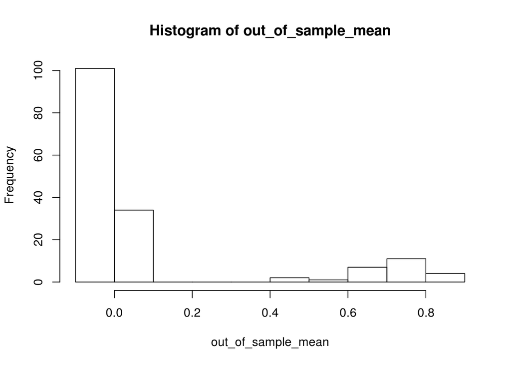

#### **Таблица 3. Данные среднемесячной доходности на тестовом множестве для лучшей по средней доходности (на обучающем множестве) стратегии**

|  | out_of_sample_mean |
| --- | --- |
| 11.07.11 | -0.019027 |
| 18.07.11 | -0.022133 |
| 25.07.11 | -0.020485 |
| 01.08.11 | -0.015342 |
| 08.08.11 | -0.003726 |
| 15.08.11 | -0.004699 |
| 22.08.11 | -0.00306 |
| 29.08.11 | -0.012358 |
| 05.09.11 | -0.010586 |
| 12.09.11 | -0.008732 |

[output cut: 150 more lines]

#### **Рисунок 2. Распределение среднемесячной доходности на тестовом множестве для лучшей по Шарпу (на обучающем множестве) стратегии**

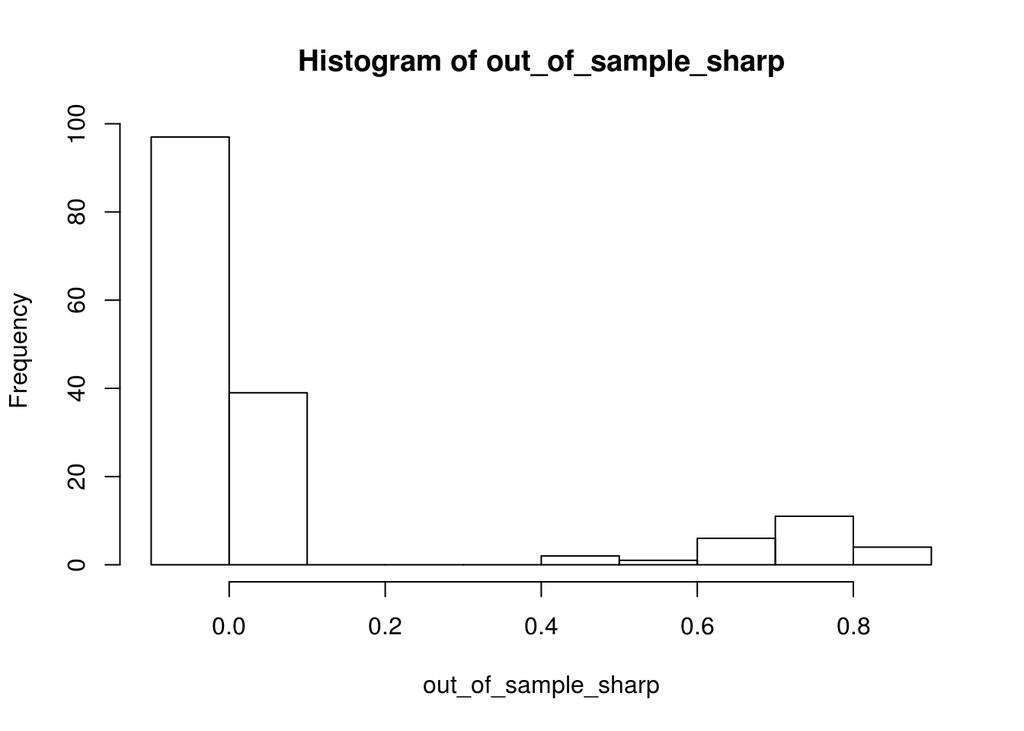

|  | out_of_sample_sharp |
| --- | --- |
| 11.07.11 | -0.01545 |
| 18.07.11 | -0.020425 |
| 25.07.11 | -0.018533 |
| 01.08.11 | -0.018006 |
| 08.08.11 | -0.004834 |
| 15.08.11 | -0.003788 |
| 22.08.11 | -0.001798 |
| 29.08.11 | -0.002682 |
| 05.09.11 | -0.010631 |
| 12.09.11 | -0.0112 |

[output cut: 150 more lines]